# Project Python Foundations: FoodHub Data Analysis

### **Question 7**: Which are the top 5 restaurants in terms of the number of orders received? [1 mark]

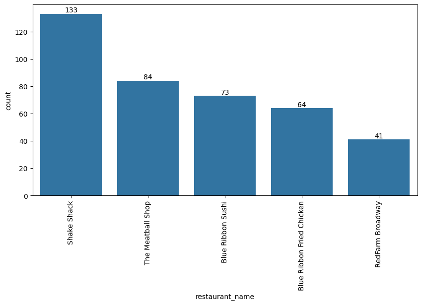

```python
# Top 5 restaurants by orders (number of rows)
plt.figure(figsize = (10,5))
ax = sns.countplot(data=data,x='restaurant_name', order=data.restaurant_name.value_counts().iloc[:5].index)
plt.xticks(rotation=90)
ax.bar_label(ax.containers[0])
plt.show()
```

#### Observations:

- The top 5 restaurants by number of orders received as indicated in the bar graph are Shake Shack (133 orders), The Meatball Shop (84 orders), Blue Ribbon Sushi (73 orders), Blue Ribbon Fried Chicken (64 orders) and RedFarm Broadway (41 orders).

### **Question 8**: Which is the most popular cuisine on weekends? [1 mark]

```python
# Number of orders by day of the week and cuisine type
data.groupby(['day_of_the_week','cuisine_type'])[['cuisine_type']].count()
```

| day_of_the_week | cuisine_type | cuisine_type |
| --- | --- | --- |
| Weekday | American | 111 |
|  | Chinese | 26 |
|  | French | 2 |
|  | Indian | 14 |
|  | Italian | 62 |
|  | Japanese | 74 |
|  | Korean | 2 |
|  | Mediterranean | 11 |
|  | Mexican | 16 |
|  | Middle Eastern | 15 |
|  | Southern | 4 |
|  | Thai | 1 |
|  | Vietnamese | 2 |
| Weekend | American | 257 |
|  | Chinese | 107 |
|  | French | 8 |
|  | Indian | 36 |
|  | Italian | 110 |
|  | Japanese | 199 |
|  | Korean | 7 |
|  | Mediterranean | 21 |
|  | Mexican | 32 |
|  | Middle Eastern | 19 |
|  | Southern | 9 |
|  | Spanish | 6 |
|  | Thai | 8 |
|  | Vietnamese | 3 |

#### Observations:

- As the summary shows, on the weekends, the most popular cuisine is American with 257 orders.

### **Question 9**: What percentage of the orders cost more than 20 dollars? [2 marks]

```python
# Number of orders that cost more than 20 dollars
data[data['cost_of_the_order']>20].shape[0]
# Total number of orders
data.shape[0]
perc = (data[data['cost_of_the_order']>20].shape[0]/data.shape[0]) * 100
print("Number of orders that cost more than 20 dollars is", data[data['cost_of_the_order']>20].shape[0])
print("Percentage of orders that cost more than 20 dollars is", round(perc, 2), "%")
```

```
Number of orders that cost more than 20 dollars is 356
Percentage of orders that cost more than 20 dollars is 30.64 %
```

#### Observations:

- The number of orders that cost more than 20 dollars is 356
- The percentage of orders that cost more than 20 dollars is 30.64 %

### **Question 10**: What is the mean order delivery time? [1 mark]

```python
# Mean of the delivery time column
data["delivery_time"].mean()
```

```
24.15404475043029
```

#### Observations:

- The mean order delivery time is 24.15 minutes

### **Question 11:** The company has decided to give 20% discount vouchers to the top 3 most frequent customers. Find the IDs of these customers and the number of orders they placed. [1 mark]

```python
# Calculate how many orders have the same customer ID and get the top customers
data['customer_id'].value_counts().head(5)
```

```
customer_id
47440     7
52832     7
65009     6
250494    6
276192    5
Name: count, dtype: int64
```

#### Observations:

- The top 3 most frequent customers are those with customer ID 47440, 52832 and 65009
- Both customers 65009 and 250494 have made 6 orders each, both competing for 3rd place. Hence either one could be selected to be in the top 3.

### **Question 12**: Perform a multivariate analysis to explore relationships between the important variables in the dataset. (It is a good idea to explore relations between numerical variables as well as relations between numerical and categorical variables) [10 marks]

#### Cuisine vs Cost of the order

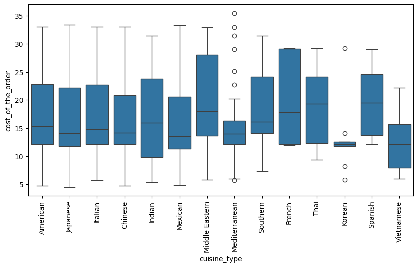

```python
#Boxplot of distribution of cost of the order by cuisine type, ordered by most popular cuisines
plt.figure(figsize = (10,5))
sns.boxplot(data=data,x='cuisine_type',y='cost_of_the_order', order=data.cuisine_type.value_counts().index)
plt.xticks(rotation=90)
plt.show()
```

#### Cuisine vs Food Preparation time

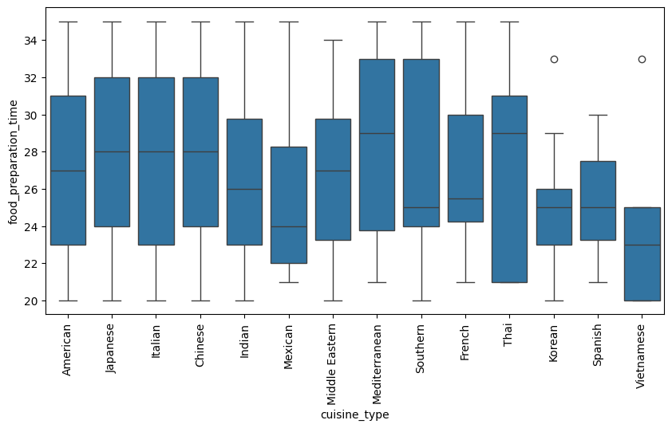

```python
#Boxplot of distribution of preparation time by cuisine type, ordered by most popular cuisines
plt.figure(figsize = (10,5))
sns.boxplot(data=data,x='cuisine_type',y='food_preparation_time', order=data.cuisine_type.value_counts().index)
plt.xticks(rotation=90)
plt.show()
```

#### Most and least expensive restaurants

```python
# Restaurants by average cost of the order
data.groupby(['restaurant_name'])['cost_of_the_order'].mean().sort_values(ascending = False).head(5)
```

```
restaurant_name
Kambi Ramen House     32.930000
Delicatessen          30.036667
Haru Gramercy Park    29.830000
Lucky Strike          29.250000
Il Bambino            29.250000
Name: cost_of_the_order, dtype: float64
```

```python
data.groupby(['restaurant_name'])['cost_of_the_order'].mean().sort_values(ascending = True).head(5)
```

```
restaurant_name
Haandi                    5.67
brgr                      5.72
Hunan Manor               5.72
Cipriani Le Specialita    5.92
Olive Garden              6.74
Name: cost_of_the_order, dtype: float64
```

#### Most and least profitable restaurants

```python
#Resturants by total cost of the orders
data.groupby(['restaurant_name'])['cost_of_the_order'].sum().sort_values(ascending = False).head(5)
```

```
restaurant_name
Shake Shack                  2225.20
The Meatball Shop            1495.65
Blue Ribbon Sushi            1170.66
Blue Ribbon Fried Chicken    1130.59
RedFarm Broadway              680.69
Name: cost_of_the_order, dtype: float64
```

```python
data.groupby(['restaurant_name'])['cost_of_the_order'].sum().sort_values(ascending = True).head(5)
```

```
restaurant_name
Haandi                    5.67
brgr                      5.72
Hunan Manor               5.72
Cipriani Le Specialita    5.92
Olive Garden              6.74
Name: cost_of_the_order, dtype: float64
```

#### Restaurants with highest and lowest average food preparation time

```python
#Restaurants by average food preparation time
data.groupby(['restaurant_name'])['food_preparation_time'].mean().sort_values(ascending = False).head(10)
```

```
restaurant_name
Klong                          35.0
Sushi Choshi                   35.0
Cipriani Le Specialita         35.0
Taro Sushi                     35.0
Kambi Ramen House              35.0
Il Bambino                     34.0
Grand Sichuan International    34.0
Ravagh Persian Grill           34.0
Hot Kitchen                    33.0
Mira Sushi                     33.0
Name: food_preparation_time, dtype: float64
```

```python
data.groupby(['restaurant_name'])['food_preparation_time'].mean().sort_values(ascending = True).head(10)
```

```
restaurant_name
Haru Gramercy Park            20.0
67 Burger                     20.0
da Umberto                    20.0
Frank Restaurant              20.0
Sarabeth's West               21.0
Bhatti Indian Grill           21.0
DespaÌ±a                      21.0
Song Thai Restaurant & Bar    21.0
Lucky Strike                  21.0
Anjappar Chettinad            21.0
Name: food_preparation_time, dtype: float64
```

#### Restaurants with highest and lowest average rating

```python
#Restaurants by average rating
data.groupby(['restaurant_name'])['rating'].mean().sort_values(ascending = False).head(10)
```

```
restaurant_name
'wichcraft                       5.0
Ravagh Persian Grill             5.0
Chola Eclectic Indian Cuisine    5.0
Chote Nawab                      5.0
Junoon                           5.0
Socarrat Paella Bar              5.0
DespaÌ±a                         5.0
Dig Inn Seasonal Market          5.0
Saravanaa Bhavan                 5.0
Donburi-ya                       5.0
Name: rating, dtype: float64
```

```python
data.groupby(['restaurant_name'])['rating'].mean().sort_values(ascending = True).head(10)
```

```
restaurant_name
Sarabeth's West             3.000000
Nha Trang One               3.000000
Haveli Indian Restaurant    3.000000
Woorijip                    3.000000
brgr                        3.000000
Byblos Restaurant           3.000000
Sushi Choshi                3.000000
Pepe Giallo                 3.000000
Cafeteria                   3.250000
Blue Ribbon Brooklyn        3.333333
Name: rating, dtype: float64
```

- The boxplots cannot show a relationship between the mean of a variable or sum of a variable and another variable, hence some specific summary statistics help us understand restaurants better within the cuisines.
- Some key highlights are as follows:
- Kabi Ramen House has the highest average cost and Haandi has the lowest average cost per order.
- Shake Shack has made the most money while Haandi has made the least.
- The restaurants with the highest average preparation time of 35 minutes are Klong, Sushi Choshi, Cipriani Le Specialita, Taro Sushi and Kambi Ramen House.
- The restaurants with the lowest average preparation time of 20 minutes are Haru Gramercy Park, 67 Burger, da Umberto and Frank Restaurant.
- There are many restaurants which a perfect average rating of 5, wheras some of the restaurants with the lowest rating are Sarabeth's West, Nha Trans One, Haveli Indian Restaurant, Woorijip, brgr, etc.

#### Day of the Week vs Delivery time

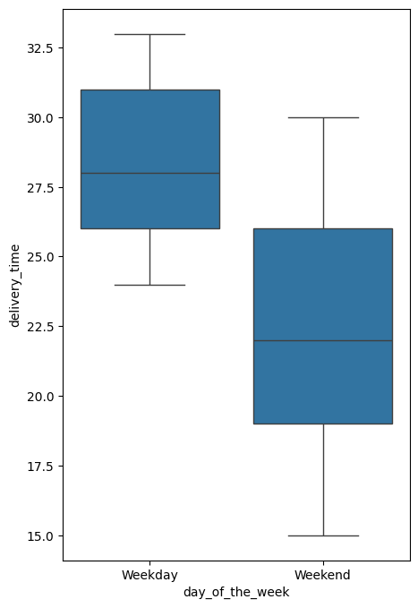

```python
#Boxplot of distribution of delivery time by day of the week
plt.figure(figsize = (5,8))
sns.boxplot(data=data,x='day_of_the_week',y='delivery_time')
plt.show()
```

- On weekdays the delivery time is much higher than that of weekends.
- On weekends there tends to be a higher variance in delivery time but lower median delivery time.
- 75% of the orders on weekdays are delivered within 31 minutes or less, but 75% of orders on the weekends are delivered within around 26 minutes or less.
- This is probably indicative of the higher resources allocated to the weekends in order to cope with more demand and cover more delivery range, considering also that there were many more orders made on the weekend than the weekdays. This explains the likely higher variance and lower median delivery time.

#### Rating vs Delivery time

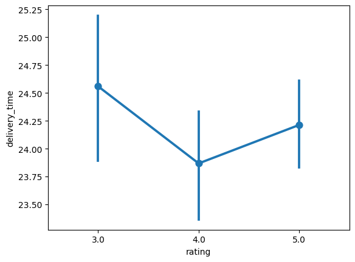

```python
#Boxplot of distribution of delivery time by rating
#plt.figure(figsize = (5,10))
sns.pointplot(data=data,x='rating',y='delivery_time')
plt.show()
```

- Orders with higher delivery time tend to have a rating of 3, while the lower delivery times have an average of 4.
- There is no obvious relationship between the increase of delivery time and the rating.
- High delivery times likely cause the customer to give the order a lower rating, but other factors may come into play when a customer gives a rating between 4 and 5 despite having low delivery times.
- It is worthwhile noting that the difference in delivery times between these ratings is very little, all within the same minute or so, hence the data may not give us much insight between delivery time and rating. It may be safe to conclude that the relationship is negligible.

#### Rating vs Food preparation time

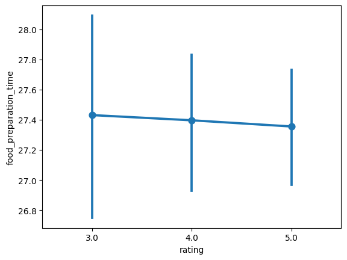

```python
#Boxplot of distribution of food preparation time by rating
sns.pointplot(data=data,x='rating',y='food_preparation_time')
plt.show()
```

- Looking at the graph, there is no notable relationship between the food preparation time and the rating of an order.
- This indicates that a customer typically doesn't rate an order as better or worse based on how long it takes the prepare. It likely depends on other factors like delivery time, or other factors like quality of the meal, satisfaction using the app etc which are not captured in this data.

#### Rating vs Cost of the order

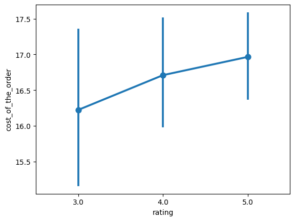

```python
#Boxplot of distribution of cost of the order by rating
sns.pointplot(data=data,x='rating',y='cost_of_the_order')
plt.show()
```

- There is an increase in the rating of an order with an increase in the cost of an order. This could indicate that the perception of the customer of a good rating may depend on how expensive and how much perceived value is placed on the order.
- Despite this trend, the actual delta between the cost of the order for the different ratings is very little, lying between 16 and 17 dollars on average. Hence it is not a big enough difference to put much weight onto this variable and deduce a strong relationship.

#### Correlation among variables

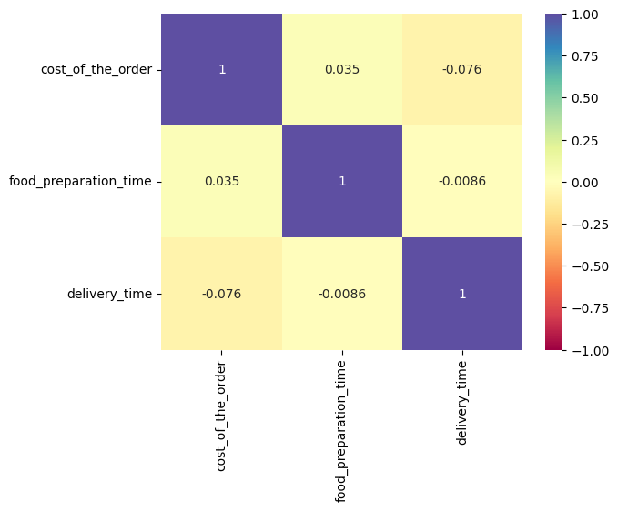

```python
#Heatmap to show correlation between the three numerical variables: Cost of the order, food delivery time and food preparation time
col_list = ['cost_of_the_order', 'food_preparation_time', 'delivery_time']
sns.heatmap(data[col_list].corr(),annot=True,cmap='Spectral',vmin=-1,vmax=1)
plt.show()
```

- The cost of the order and the food preparation time have a small positive correlation of 3.5%, which is very weak.
- The cost of the order and delivery time have a negative correlation of 7.6%, which is also weak.
- The delivery time and food preparation time has a very low negative correlation of 0.86%, which indicates that they hardly affect each other at all.
- From this heatmap an correlation analysis, it is safe to conclude that none of the numerical variables in our dataset have a strong correlation with each other.

### **Question 13:** The company wants to provide a promotional offer in the advertisement of the restaurants. The condition to get the offer is that the restaurants must have a rating count of more than 50 and the average rating should be greater than 4. Find the restaurants fulfilling the criteria to get the promotional offer. [3 marks]

```python
#Restaurants with rating count more than 50
restaurants_rating_count_50 = data.groupby(['restaurant_name'])['rating'].count()
restaurants_rating_count_50 = restaurants_rating_count_50[restaurants_rating_count_50 > 50].reset_index()

#Restaurants with average rating greater than 4
restaurants_rating_4 = data.groupby(['restaurant_name'])['rating'].mean()
restaurants_rating_4 = restaurants_rating_4[restaurants_rating_4 > 4].reset_index()

qualifying_resturants = restaurants_rating_count_50.merge(restaurants_rating_4, left_on='restaurant_name', right_on='restaurant_name', how='inner')
qualifying_resturants
```

|  | restaurant_name | rating_x | rating_y |
| --- | --- | --- | --- |
| 0 | Blue Ribbon Fried Chicken | 64 | 4.328125 |
| 1 | Blue Ribbon Sushi | 73 | 4.219178 |
| 2 | Shake Shack | 133 | 4.278195 |
| 3 | The Meatball Shop | 84 | 4.511905 |

#### Observations:

- First using a groupby to get the restaurants with at least 50 ratings and then using groupby again to get restaurants with at least 4.0 average rating, and then doing an inner join on both lists gives us the list of restaurants that qualify for the promotion.
- Hence the restaurants that fulfil the criteria for the promotion are Blue Ribbon Fried Chicken, Blue Ribbon Sushi, Shake Shack and The Meatball Shop.

### **Question 14:** The company charges the restaurant 25% on the orders having cost greater than 20 dollars and 15% on the orders having cost greater than 5 dollars. Find the net revenue generated by the company across all orders. [3 marks]

```python
# Calculate an extra column in the data frame to generate the extra revenue per order
data['cost_20'] = np.where(data['cost_of_the_order'] > 20, 0.25 * data['cost_of_the_order'], 0)
data['cost_5'] = np.where((data['cost_of_the_order'] > 5) & (data['cost_of_the_order'] <= 20), 0.15 * data['cost_of_the_order'], 0)
data['extra_revenue'] = data['cost_20'] + data['cost_5']
data.sample(5)
```

|  | order_id | customer_id | restaurant_name | cuisine_type | cost_of_the_order | day_of_the_week | rating | food_preparation_time | delivery_time | cost_20 | cost_5 | extra_revenue |
| --- | --- | --- | --- | --- | --- | --- | --- | --- | --- | --- | --- | --- |
| 713 | 1478001 | 64153 | Blue Ribbon Fried Chicken | American | 31.38 | Weekend | 3.0 | 35 | 20 | 7.8450 | 0.0000 | 7.8450 |
| 481 | 1477877 | 360844 | RedFarm Broadway | Chinese | 19.35 | Weekend | 5.0 | 33 | 18 | 0.0000 | 2.9025 | 2.9025 |
| 1840 | 1476843 | 361846 | Sarabeth's West | American | 14.12 | Weekday | 3.0 | 21 | 33 | 0.0000 | 2.1180 | 2.1180 |
| 1006 | 1477395 | 56219 | Parm | Italian | 14.55 | Weekday | 5.0 | 30 | 32 | 0.0000 | 2.1825 | 2.1825 |
| 891 | 1477140 | 366954 | Blue Ribbon Sushi | Japanese | 24.25 | Weekend | 5.0 | 35 | 16 | 6.0625 | 0.0000 | 6.0625 |

```python
data['extra_revenue'].sum()
```

```
3865.572
```

#### Observations:

- The orders above 20 dollars have a charge of 25% and the orders above 5 dollars have a charge of 15%, which have been calculated per order and the column extra_revenue describes the extra_revenue generated per order.
- Getting the sum of all the extra revenues, the company generated 3865.57 dollars across all orders.

### **Question 15:** The company wants to analyze the total time required to deliver the food. What percentage of orders take more than 60 minutes to get delivered from the time the order is placed? (The food has to be prepared and then delivered.) [2 marks]

```python
# Calculate total delivery time as the sum of food preparation time and delivery time
data['total_time'] = data['food_preparation_time'] + data['delivery_time']
# Orders that took more than 60 minutes total
data_60 = data[data['total_time'] > 60]
print(data_60.shape[0], 'orders took more 60 minutes to get delivered')
print(round(data_60.shape[0] / data.shape[0] * 100,3), '% of orders took more 60 minutes to get delivered')
```

```
119 orders took more 60 minutes to get delivered
10.241 % of orders took more 60 minutes to get delivered
```

#### Observations:

- 119 orders took more 60 minutes to get delivered, from the time the order is placed
- Hence, 10.241 % of orders took more 60 minutes to get delivered

### **Question 16:** The company wants to analyze the delivery time of the orders on weekdays and weekends. How does the mean delivery time vary during weekdays and weekends? [2 marks]

```python
# Calculating average delivery time based on day of the week
data.groupby(['day_of_the_week'])['delivery_time'].mean()
```

```
day_of_the_week
Weekday    28.305882
Weekend    22.436740
Name: delivery_time, dtype: float64
```

#### Observations:

- Grouping the day by day of the week and then calculating the average delivery time, we can see that on weekdays the average delivery time is about 28 minutes and on weekends it is about 22 minutes.
- As seen previously in our graphical analysis, the delivery time is higher on weekdays than on weekends by about 6 minutes on average.

### Recommendations:

Based on the exploratory data anlysis, the business can find patterns in the customer behaviour and potentially act on the following recommendations

- Incentivize more sales on the weekdays with lower cost and better delivery times
- Promote the most popular restaurants using marketing campaigns, loyalty programs, discounts for regular customers.
- Deducing what are the most popular restaurants and quickest total time for restaurants for both weekends and weekdays and suggest those to customers for higher ratings.
- Incentivize users to rate the orders because of large missing data. The more data there is, the better the analysis we can do. Potentially adding a discount for every 10 reviews or something similar.